# Mixture models

### intro

Recall types of clustering methods:

- hard clustering: clusters do not overlap
- soft clustering: clusters may overlap (**mixture models**)

Mixture models:

- probabilistically-grounded way of doing soft clustering (each cluster corresponds to probability distribution)
- each cluster: a generative model (Gaussian or multinomial)
- parameters (mean/covariance are unknown)

\begin{equation} \left[ \begin{array} \\ P(a\ |\ x_i) = \frac{P(x_i|a)P(a)}{P(x_i|a)P(a) + P(x_i|a)P(a)} \\ P(b\ |\ x_i) = \frac{P(x_i|b)P(b)}{P(x_i|a)P(a) + P(x_i|b)P(b)} \\ \end{array} \right. \end{equation}

$P(a\ |\ x_i) = \frac{P(x_i|a)P(a)}{P(x_i|a)P(a) + P(x_i|a)P(a)}$

$P(b\ |\ x_i) = \frac{P(x_i|b)P(b)}{P(x_i|a)P(a) + P(x_i|b)P(b)}$

# Mixture models in 1-d

**Problem:** There are observations $x_1,x_2,...,x_n$, $x_i \in R^1$ Half of them comes from gaussiana $a$, half of them comes from gaussiana $b$. For each $x_i$ we don't know source. **Q:** Estimate parameters ($\mu_a$, $\sigma_a$) and ($\mu_b$, $\sigma_b$) of each gaussian.

**Expectation Maximization:**

1. start with random ($\mu_a$, $\sigma_a$) and ($\mu_b$, $\sigma_b$)
2. for each point, calculate $P(b|x_i)$ and $P(a|x_i)$ - probabilities that it look like it came from $b$-guassian and $a$-guassian:

   \begin{equation} \left[ \begin{array} \\ P(a\ |\ x_i) = \frac{P(x_i|a)P(a)}{P(x_i|a)P(a) + P(x_i|a)P(a)} \\ P(b\ |\ x_i) = \frac{P(x_i|b)P(b)}{P(x_i|a)P(a) + P(x_i|b)P(b)} \\ \end{array} \right. \end{equation}

   where,

   ```
    \mu_a = \frac{\sum_{i=1}^{n}{P(a|x_i){\cdot}x_i}}
            {\sum_{i=1}^{n}{P(a|x_i)}} \\
    \mu_b = \frac{\sum_{i=1}^{n}{P(b|x_i){\cdot}x_i}}
            {\sum_{i=1}^{n}{P(b|x_i)}} \\
    \sigma_a = \frac{\sum_{i=1}^{n}{P(a|x_i){\cdot}(x_i-\mu_a)^2}}
            {\sum_{i=1}^{n}{P(a|x_i)}} \\
    \sigma_b = \frac{\sum_{i=1}^{n}{P(b|x_i){\cdot}(x_i-\mu_b)^2}}
            {\sum_{i=1}^{n}{P(b|x_i)}} \\
   ```

### Implementation

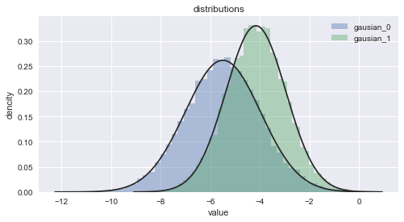

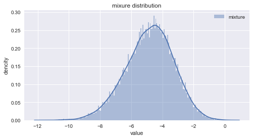

|  | names | mean | variance |
| --- | --- | --- | --- |
| 0 | gausian_0 | -5.453110 | 2.341148 |
| 1 | gausian_1 | -4.166871 | 1.438537 |

```python
import random
import numpy as np
import pandas as pd
import matplotlib.pyplot as plt
import seaborn as sns
import scipy.stats
from IPython.display import Image, display

__version__ = '0.0.1'
__author__ = 'Denis Kuzin <denkuzin@yandex.ru>'

# generate notmally distributed 1-D vectors and mix up them

num_gaus = 2  # number of gaussians
num_examples_per_gaus = 10000
num_iterations = 50

feature = []
means = []
variances = []

for _ in range(num_gaus):
    mean = random.uniform(-10,10)
    means.append(mean)
    variance = random.uniform(1,5)
    variances.append(variance)
    means.sort()

for i in range(num_gaus):
    feat = np.random.normal(means[i], np.sqrt(variances[i]), size=(num_examples_per_gaus,))
    feature.append(feat)

feature_all = np.hstack(feature)


# visualization
fig = plt.figure(figsize=(8,4))
for i in range(num_gaus):
    sns.distplot(feature[i], bins = 50, hist = True, kde = False,
                 fit=scipy.stats.norm, label="gausian_{}".format(i))
plt.title("distributions")
plt.xlabel("value")
plt.ylabel("dencity")
plt.legend();
plt.show()

fig = plt.figure(figsize=(8,4))
sns.distplot(feature_all, bins = 200, kde = True, label="mixture")
plt.title("mixure distribution")
plt.xlabel("value")
plt.ylabel("dencity")
plt.legend()
plt.show()

names = ["gausian_{}".format(i) for i in range(num_gaus)]
df = pd.DataFrame(list(zip(names, means, variances)),
             columns=["names", "mean", "variance"])
df
```

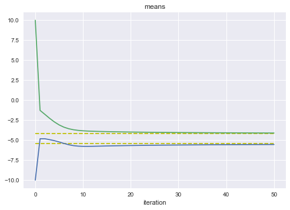

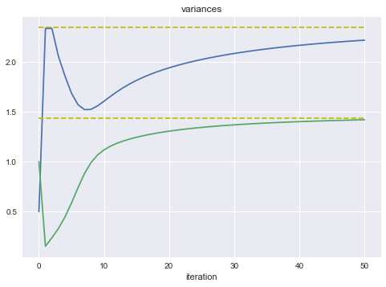

|  | names | means | means_est | means_error | variances | variance_est | variances_error |
| --- | --- | --- | --- | --- | --- | --- | --- |
| 0 | gausian_0 | -5.453110 | -5.543587 | 0.016592 | 2.341148 | 2.216073 | 0.053425 |
| 1 | gausian_1 | -4.166871 | -4.107469 | 0.014256 | 1.438537 | 1.419463 | 0.013259 |

```python
#1. initialisation of means and variances
num_clusters = num_gaus

means_est = np.linspace(-10,10,num = num_clusters).tolist()
variances_est = [a/2 for a in range(1, num_clusters+1)]
print ("initial values of mean = {}".format(means_est))
print ("initial values of variance = {}".format(variances_est))

#placeholders for probabilities the point to belong to cluster i
prob_cluster_x = [np.zeros(feature_all.shape)]*num_clusters
prob_x_cluster = [np.zeros(feature_all.shape)]*num_clusters

stats = []
stats.append((means_est.copy(), variances_est.copy()))

def probability_normal(feature, mean, variance):
    prefix = 1/np.sqrt(2*np.pi*variance)
    exp = np.exp(-((feature-mean)**2)/2/variance)
    return prefix*exp

def conditional_probability(prob_x_cluster, i):
    numerator = (1.0/num_clusters)*prob_x_cluster[i]
    denominator = 0.5*np.sum(prob_x_cluster, axis=0)
    return numerator/denominator

def weighted_mean_and_var(p_cluster, feature):
    mean = np.sum(p_cluster * feature)/np.sum(p_cluster)
    var = np.sum(p_cluster * (feature - mean)**2)/np.sum(p_cluster)
    return mean, var

for _ in range(num_iterations):

    # 2. for each point calculate $P(cluster_i|x_i)$
    for i in range(num_clusters):
        prob_x_cluster[i] = probability_normal(
                    feature_all, means_est[i], variances_est[i])
        prob_cluster_x[i] = conditional_probability(prob_x_cluster, i)

    # 3. adjust means and variances
    for i in range(num_clusters):
        means_est[i], variances_est[i] = weighted_mean_and_var(
                prob_cluster_x[i], feature_all)

    stats.append((means_est.copy(), variances_est.copy()))

names = ["gausian_{}".format(i) for i in range(num_gaus)]
means_error = [abs(a - b)/abs(a) for a,b in zip(means, means_est)]
variances_error = [abs(a - b)/abs(a) for a,b in \
                       zip(variances, variances_est)]

# visualization
for i in range(2*num_clusters):
    x_axis = list(range(len(stats)))
    targets = []
    estimats = []
    both_targets = means + variances

    for record in stats:
        both = record[0] + record[1]

        targets.append(both_targets[i])
        estimats.append(both[i])
    plt.plot(x_axis, targets, 'y--')
    plt.plot(x_axis, estimats)
    if i == num_clusters-1:
        plt.title("means")
        plt.xlabel("iteration")
        plt.show()
plt.title("variances")
plt.xlabel("iteration")
plt.show()

df = pd.DataFrame(
        list(zip(names, means, means_est, means_error,
                 variances, variances_est, variances_error)),
        columns=["names","means","means_est","means_error",
                 "variances","variance_est","variances_error"])
df
```

# Mixture models in k-d space

**Problem:** There are observations $\vec{x_1},\vec{x_2},...,\vec{x_n}$, $\vec{x_i} \in R^k$. The same parts of observations come from gaussians $c$, all numbers of gaussians is $N$. For each $\vec{x_i}$ we don't know the source gaussian. **Q:** Estimate parameters ($\vec{\mu_c}$, $\Sigma_{c}$) for each gaussian $c$, $\vec{\mu_с} \in R^k$, $\Sigma_{c} \in S^{k}_{++}$

$k$ - dimensionality of $x_i$

**Expectation Maximization:**

   where,

   \begin{equation} \left[ \begin{array} \\ P(c) = \frac{1}{N}\ \ \ \text{# the same number of observation} \\ P(x_i\ |\ c) = \frac{1}{\sqrt{2\pi|\Sigma_{a}|}} exp\{-\frac{1}{2}(\vec{x_i} - \mu_c)^{T}\Sigma_{c}^{-1}(\vec{x_i} - \mu_c)\} \\ \Sigma_c = E[xx^T] -\mu_c\mu_{c}^T \end{array}\right. \end{equation}
3. adjust ($\vec{\mu_c}$, $\Sigma_c$) \begin{equation} \left[ \begin{array} \\ w_i = \frac{P(c|\vec{x_i})}{\sum_{i=1}^{n}{P(c|\vec{x_i})}} \\ \vec{\mu_c} = \sum_{i=1}^{n}{w_i\cdot\vec{x_i}} \\ \Sigma_c = \sum_{i=1}^{n}{[(w_i\vec{x_i} - \vec{\mu_c})\cdot(w_i\vec{x_i} - \vec{\mu_c})^{T}]} \end{array}\right. \end{equation}
4. iterate until convergence

# Appendix

link_1: https://goo.gl/ErX1xN

link_2: https://goo.gl/cQaRNV

link_3: https://goo.gl/ZmpTSe

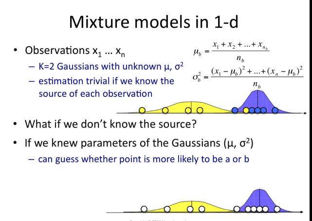

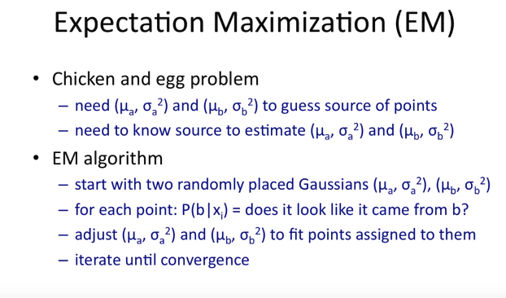

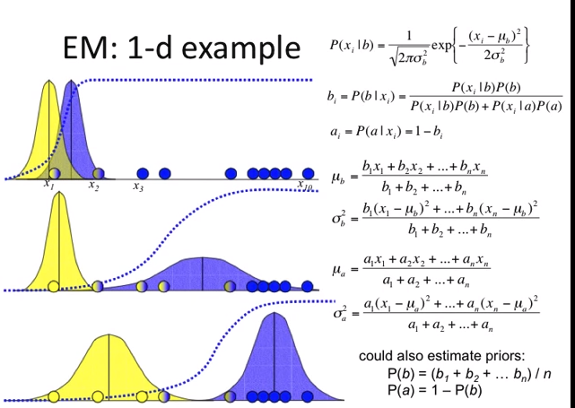

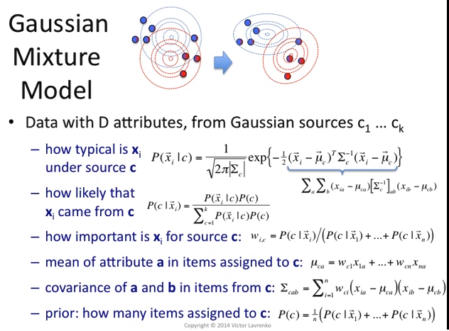

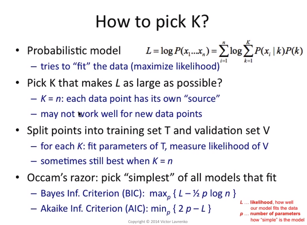

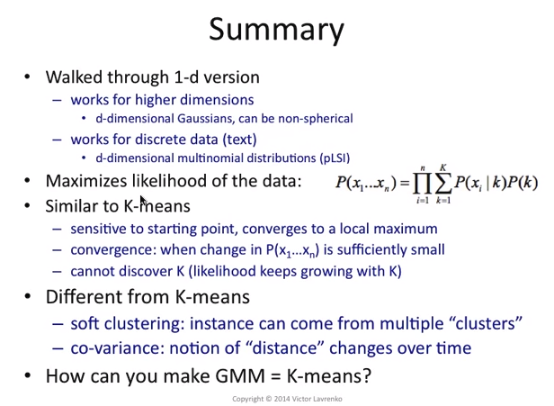

```python
paths = ["pics/pic1.png",
         "pics/pic2.png",
         "pics/pic3.png",
         "pics/pic4.png",
         "pics/pic5.png",
         "pics/pic6.png"]
images = []
for path in paths:
    images.append(Image(filename=path))
display(*images)
```

```python
reset -fs
```